# 08. Interpreting the Black Box with SHAP & survex

## Introduction

Machine learning models are notoriously criticized as “black boxes.” While they often achieve superior predictive performance, clinicians need to know *why* a model is making a specific prediction.

`SuperSurv` solves this using **SHAP (SHapley Additive exPlanations)**. Because Shapley values possess the mathematical property of linearity, `SuperSurv` can calculate the SHAP values for every active base learner and seamlessly combine them using the meta-learner’s weights.

This tutorial covers Global feature importance, Local (patient-level) explanations, and Time-Dependent survival analysis using the `survex` package.

## 1. Setup and Model Fitting

Let’s train a diverse Super Learner on our `metabric` dataset.

```r
library(SuperSurv)
library(survival)

data("metabric", package = "SuperSurv")
set.seed(42)

train_idx <- sample(1:nrow(metabric), 0.7 * nrow(metabric))
train <- metabric[train_idx, ]
test  <- metabric[-train_idx, ]

X_tr <- train[, grep("^x", names(metabric))]
X_te <- test[, grep("^x", names(metabric))]
new.times <- seq(50, 200, by = 25)
X_explain_subset <- X_te[1:50, ]
X_background_subset <- X_tr[1:100, ]

my_library <- c("surv.coxph", "surv.weibull")
if (has_rfsrc) {
  my_library <- c(my_library, "surv.rfsrc")
}

fit_sl <- SuperSurv(
  time = train$duration,
  event = train$event,
  X = X_tr,
  newdata = X_te,
  new.times = new.times,
  event.library = my_library,
  cens.library = c("surv.coxph"),
  verbose = FALSE,
  selection = "ensemble",
  nFolds = 3
)
```

## 2. Global Explanations (Kernel SHAP)

To calculate static risk SHAP values, we need an `X_explain` dataset (the patients we want to explain) and an `X_background` dataset (a reference population used to calculate the baseline average risk).

```r
# Calculate weighted Ensemble SHAP values using Kernel SHAP
shap_vals <- explain_kernel(
  model = fit_sl,
  X_explain = X_explain_subset,
  X_background = X_background_subset,
  nsim = 20
)
```

### Global Importance Bar Plot

Which features drive the ensemble’s mortality risk predictions across the entire cohort?

```r
plot_global_importance(shap_vals, top_n = 5)
```

[output not shown]

### SHAP Beeswarm Summary Plot

The beeswarm plot is the gold standard for SHAP. It shows both the magnitude of a feature’s impact and the direction of its effect.

```r
plot_beeswarm(shap_vals, data = X_explain_subset, top_n = 5)
```

[output not shown]

*Interpretation: A red dot (high feature value) on the right side of the vertical zero-line indicates that higher values of this biomarker increase mortality risk.*

## 3. Local (Patient-Level) Explanations

In precision medicine, we often need to explain why a *specific* patient has a high risk score. The Waterfall plot breaks down the exact algorithmic logic for an individual.

```r
# Explain Patient #1 from our test subset
plot_patient_waterfall(shap_vals, patient_index = 1, top_n = 5)
```

[output not shown]

## 4. Feature Dependence Plots

Does a specific biomarker have a linear or non-linear relationship with mortality risk?

```r
plot_dependence(shap_vals, data = X_explain_subset, feature_name = "x0")
```

[output not shown]

## 5. Patient Risk Trajectories (Survival Heatmap)

We can visualize patient trajectories over time using a survival heatmap generated directly from `SuperSurv` predictions.

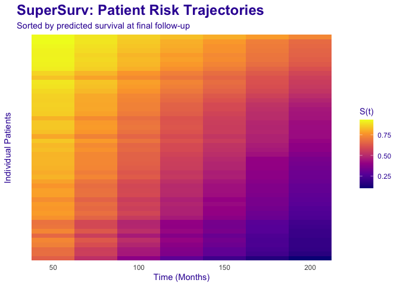

```r
# Plot the survival trajectories for the first 50 test patients
plot_survival_heatmap(fit_sl, newdata = X_explain_subset, times = new.times)
```

## 6. Time-Dependent Explanations (`survex` Integration)

Traditional SHAP looks at an overall “risk score,” but survival analysis is fundamentally about *time*. A feature might be highly predictive of early mortality (Time = 50) but irrelevant for long-term survival (Time = 200).

`SuperSurv` natively bridges to the `survex` package to evaluate dynamic feature importance across the entire survival curve $S(t)$.

```r
library(survex)

# 1. Create the true survival object for the explanation subset
y_explain <- survival::Surv(test$duration[1:50], test$event[1:50])

# 2. Build the survex explainer using our custom function
surv_explainer <- explain_survex(
  model = fit_sl,
  data = X_explain_subset,
  y = y_explain,
  times = new.times
)
```

Once the explainer is created, you have full access to the `survex` ecosystem. Let’s look at three powerful time-dependent visualizations.

### A. Dynamic Feature Importance

Which features are driving the model’s predictions at different clinical milestones?

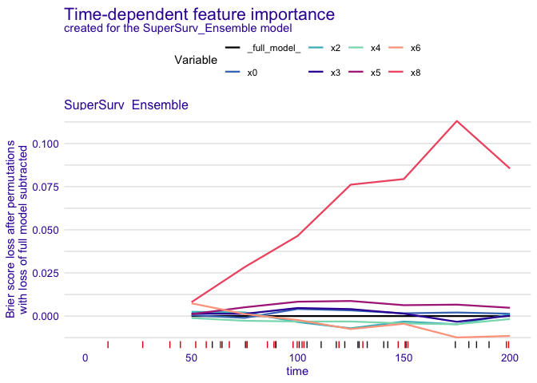

```r
# Calculate time-dependent model parts (permutation feature importance)
time_importance <- model_parts(surv_explainer)

# Plot the dynamic importance over time
plot(time_importance)
```

*Interpretation: If a feature’s curve rises over time, it means that biomarker becomes more critical for predicting long-term survival.*

### B. Time-Dependent Partial Dependence Profiles

How does the value of a specific continuous feature (e.g., `x0`) change the average survival probability over time?

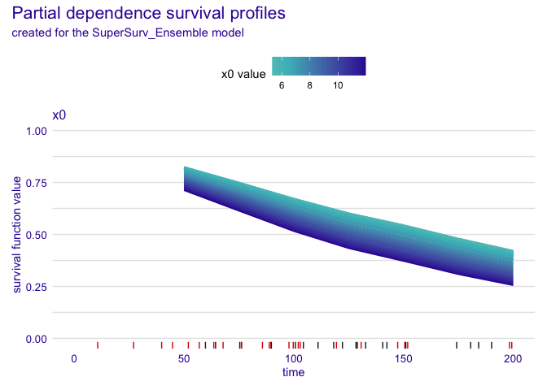

```r
# Calculate the partial dependence profile for feature 'x0'
pdp_time <- model_profile(surv_explainer, variables = "x0")

plot(pdp_time)
```

*Interpretation: This generates a 3D-like profile showing how different values of `x0` shift the entire survival curve.*

### C. SurvSHAP(t): Local Explanations Over Time

Just like the Waterfall plot explains a static risk score, SurvSHAP(t) explains exactly how a specific patient’s features pushed their survival probability up or down *at every single time point*.

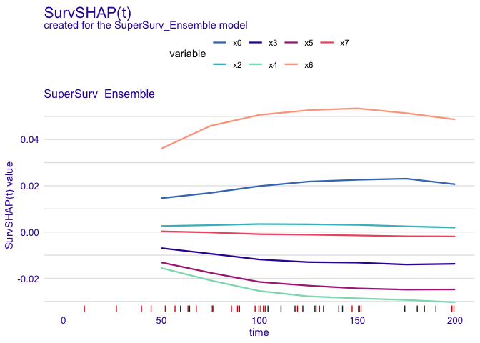

```r
# Explain Patient #1 over time
patient_1_data <- X_explain_subset[1, , drop = FALSE]

# Calculate SurvSHAP(t)
survshap_t <- predict_parts(surv_explainer, new_observation = patient_1_data, type = "survshap")

plot(survshap_t)
```

### D. Ecosystem Compatibility: Global Model Performance

Because `explain_survex()` creates a standard explainer object, you aren’t just limited to SHAP values. You can utilize the entire `survex` ecosystem, including their built-in performance metrics.

While `SuperSurv` provides its own comprehensive benchmarking suite (`plot_benchmark`), you can easily cross-validate your ensemble’s Time-Dependent Brier Score and AUC using `survex`’s native functions:

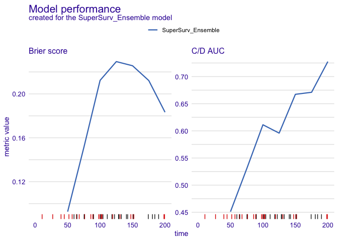

```r
# Calculate time-dependent performance metrics via survex
survex_perf <- model_performance(surv_explainer)

# Plot the Brier score and AUC curves
plot(survex_perf)
```

*Note: The Brier score should ideally stay as low as possible over time, while the AUC should remain high. This serves as an excellent independent validation of the results generated by `SuperSurv`’s native `eval_summary()`!*

By utilizing these tools, `SuperSurv` ensures that your advanced machine learning ensembles remain completely transparent, dynamically interpretable, and ready for clinical deployment.